# Your Contrasts May Be Wrong: a statistical PSA

Laurel Brehm

# The MEM switch

Since 2008, psycholinguistics has switched from using ANOVA to using mixed effect models (MEM).

This was sold to us for a few reasons:

1. Crossed random effects – which means no need to aggregate/average dependant measures!
2. Ability to include continuous and categorical predictors
3. Ability to analyse continuous and categorical data.

# The MEM (bait and) switch

Since 2008, psycholinguistics has switched from using ANOVA to using mixed effect models (MEM).

This was sold to us for a few reasons:

1. Crossed random effects – which means no need to aggregate/average dependant measures!
2. Ability to include continuous and categorical predictors
3. Ability to analyse continuous and categorical data.

–> MEMs are really powerful at describing data of lots of types.

# The MEM (bait and) switch

Since 2008, psycholinguistics has switched from using ANOVA to using mixed effect models (MEM).

This was sold to us for a few reasons:

1. Crossed random effects – which means no need to aggregate/average dependant measures!
2. Ability to include continuous and categorical predictors
3. Ability to analyse continuous and categorical data.

–> MEMs are really powerful at describing data of lots of types.

–> *This means that the user needs to make choices, and why/how is not always transparent.*

*Contrasts are one of these topics.*

# This presentation is an abbreviated version of a full paper

You can read this for more details:

[figure not shown]

# What’s an MEM?

Mixed effect models follow this general formula:

*Dependent Measure = Predictor + Variance Component + Error*

or if you like…

*Y = Fixed Effect + Random Effect + Residual*

# MEM = regression

This is the form of a regression equation. Mixed models are a regression.

*Dependent Measure = Predictor + Variance Component + Error*

# MEM = regression

This is the form of a regression equation. Mixed models are a regression.

*Dependent Measure = Predictor + Variance Component + Error*

And a regression… is a line.

# Regression = lines

Drawing a line is easy when you have predictors that are numbers.

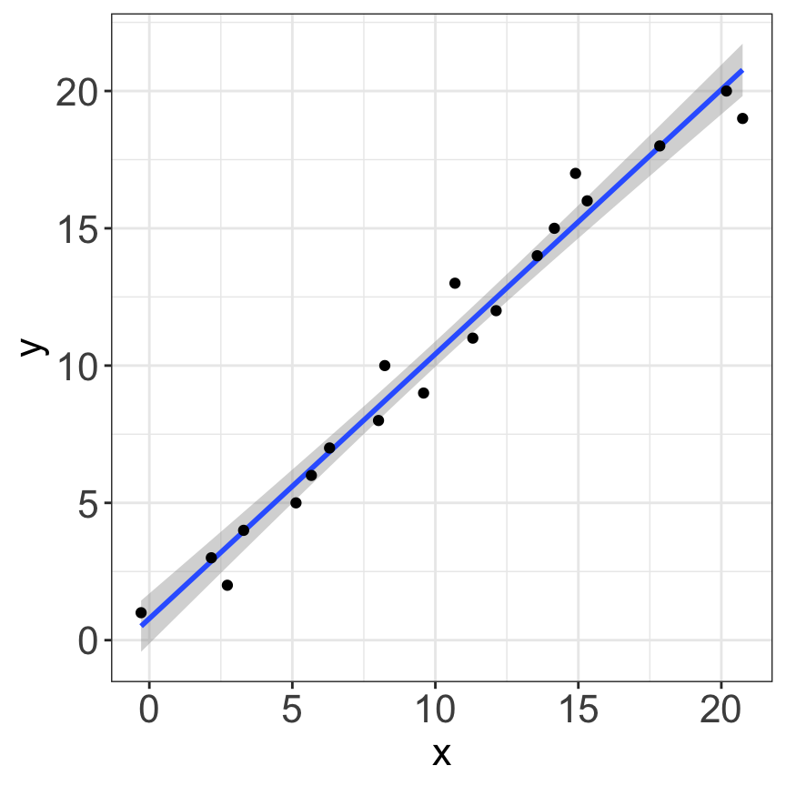

# Regression = lines

Drawing a line is easy when you have predictors that are numbers.

To draw a line between variable levels that are not numbers, you need to make some choices.

R’s default choices may not be doing what you think.

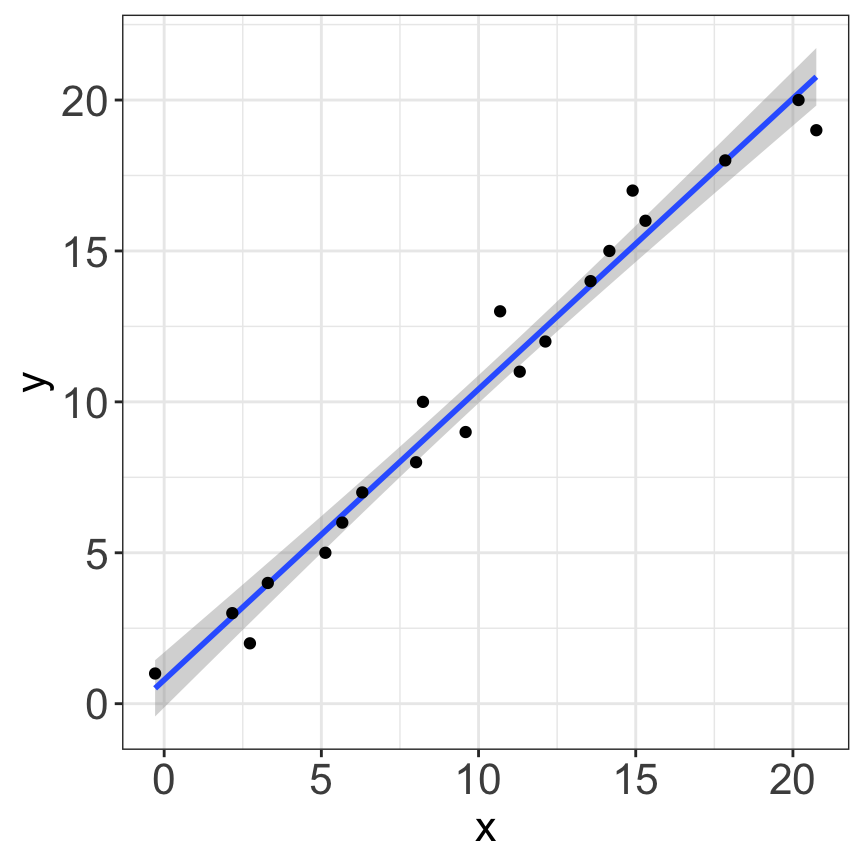

# Regression = lines

Let’s now consider a hypothetical study as example.

I want to assess the role of coffee consumption on picture naming response time.

I give some of my participants normal cups of espresso (160 ml). I give some of my participants big mugs of espresso (350 ml). Everybody names 100 pictures quickly; I measure their RT.

[figure not shown]

[figure not shown]

# Drawing lines: Numbers

I could operationalize my predictor in terms of the number of mL coffee consumed.

I can then draw my line (= run a regression)

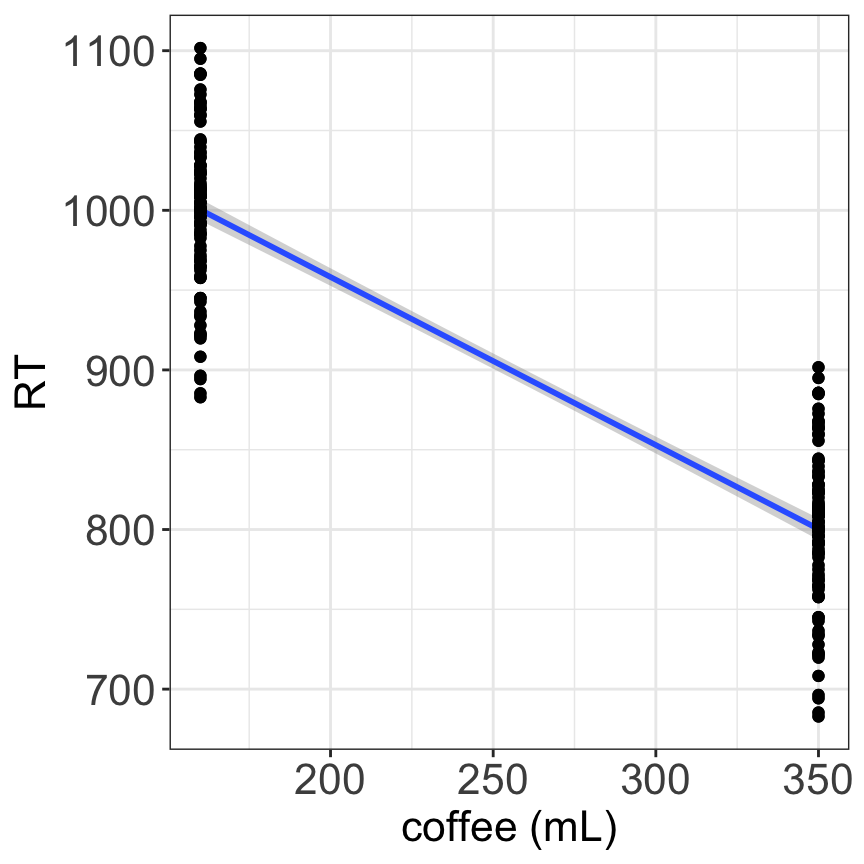

# Drawing lines: Effects

I could also operationalize my predictor in terms of the difference in mL from the average.

I can then draw my line (= run a regression)

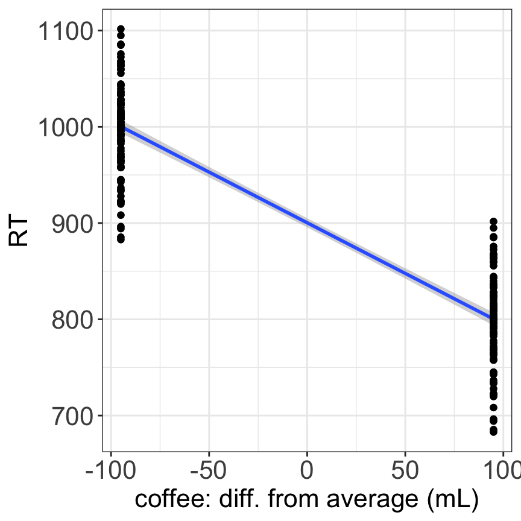

# Drawing lines: Dummy

Or, I could operationalize my predictor in terms of how much more coffee the big-mug group got.

I can then draw my line (= run a regression)

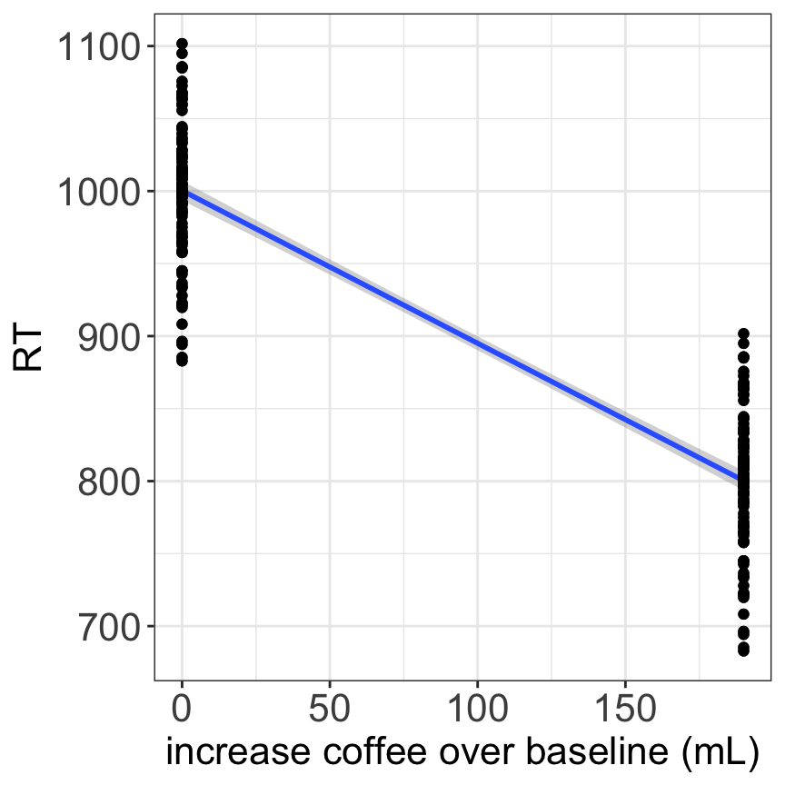

# Same lines, different intercepts

Each of these lines has the same shape: the slope is exactly the same, and the variance around it is exactly the same.

What is different is their intercepts. We’ll come back to what this means in a minute.

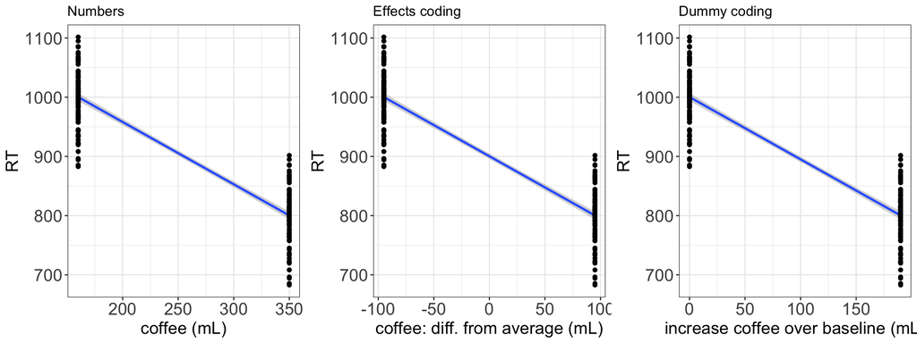

# Still works with categories…

If we code our serving sizes instead as “cup” and “mug”, we can in fact still run a regression by *making up* x values!

This is what setting contrasts is, effectively.

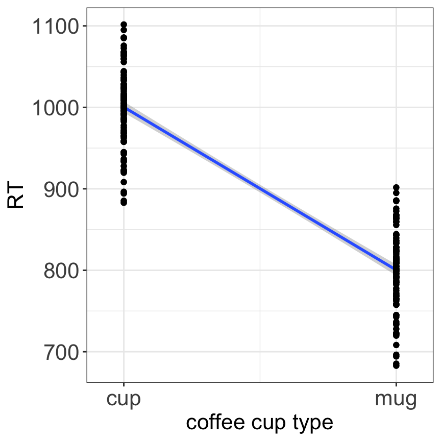

# R’s default contrast coding = Dummy

The default contrast coding scheme in R is to set the alphabetically first value with the contrast 0, and the other one as 1.

This is called ‘dummy coding’ or ‘treatment coding’ or ‘baseline coding’.

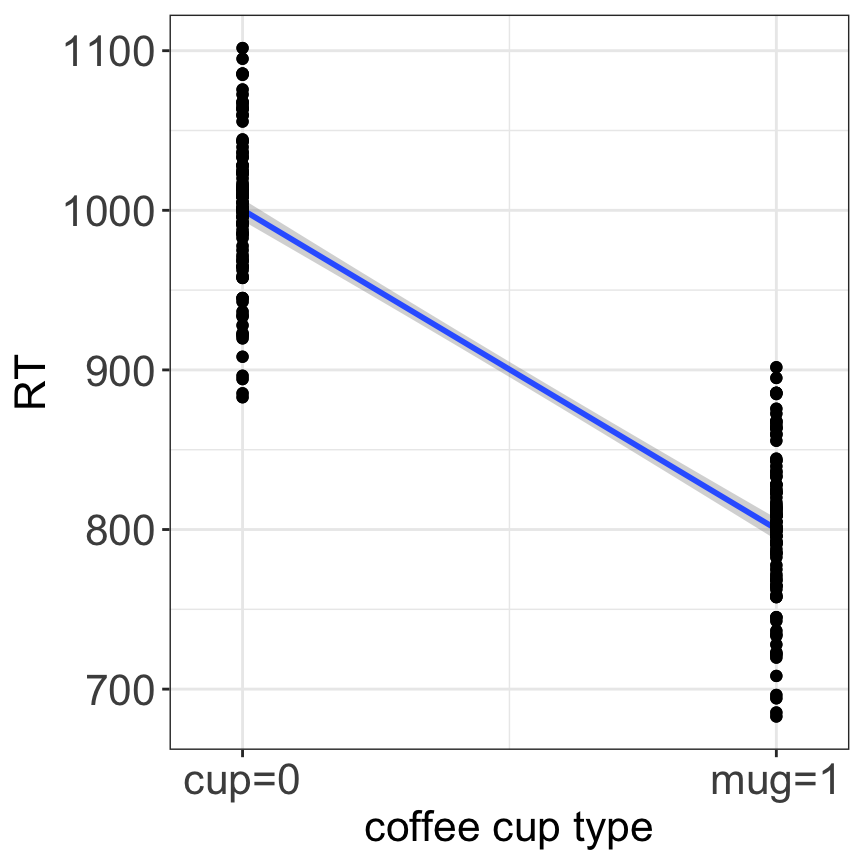

# R’s default contrast coding = Dummy

The default contrast coding scheme in R is to set the alphabetically first value with the contrast 0, and the other one as 1.

This is called ‘dummy coding’ or ‘treatment coding’ or ‘baseline coding’.

In R, this is easily checked with a bit of code:

```
contrasts(d$coffee)
      mug
cup    0
mug    1
```

# Another option: Effects coding

Another coding scheme is to set one level as -1, and another level as 1. This is known as ‘effects coding’.

This is not the R default. But it is what corresponds to your intuitions about effects in models.

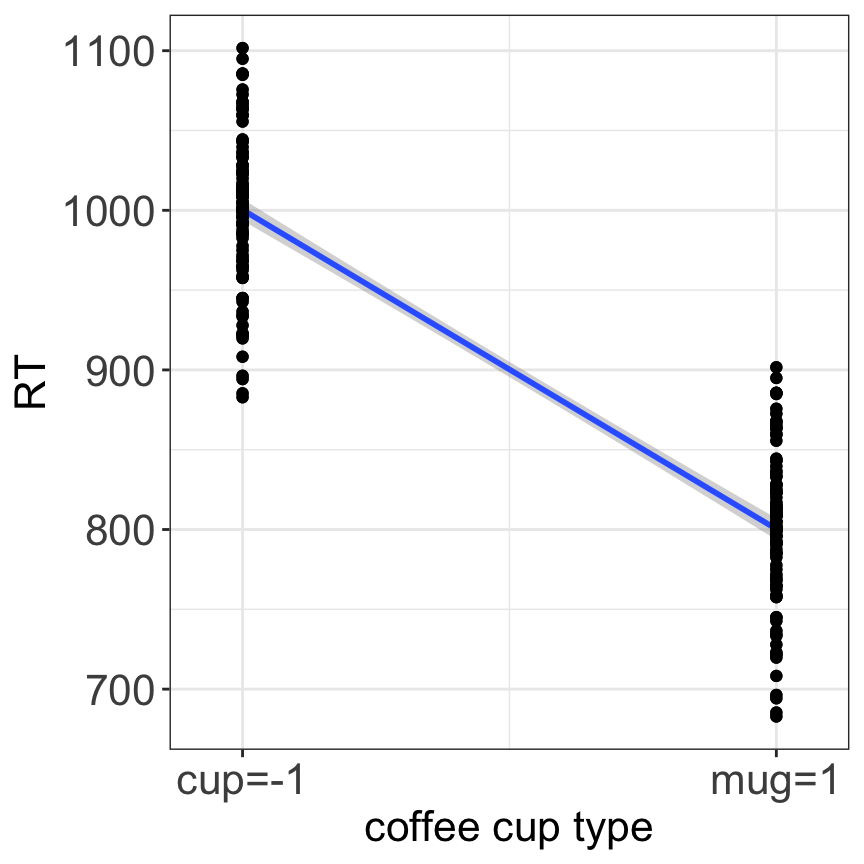

# Another option: Effects coding

This is again easily set with a bit of code:

```
contrasts(d$coffee) <- c(-1,1)

contrasts(d$coffee)
      mug
cup    -1
mug    1
```

# Same lines, different intercepts

The reason why these give different interpretations relates to the intercept: y where x=0

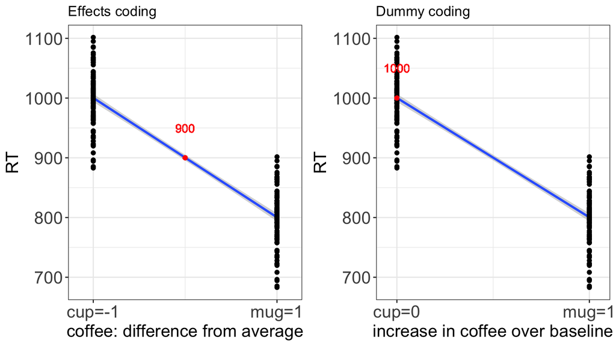

# Same lines, different intercepts

In the effects coding case, the intercept has been placed in the middle. This means that the intercept reflects the average effect, collapsing across coffee size.

In the dummy coding case, the intercept reflects the baseline level– the normal coffee size.

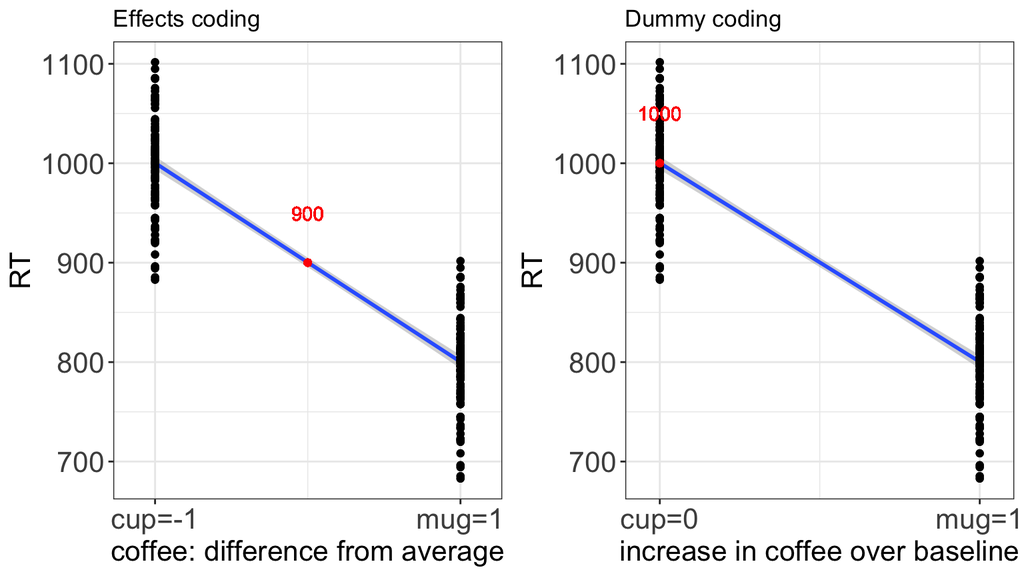

# Main effects matter

In the effects coding case:

since the intercept is in the middle, the main effect of ‘coffee’ in our model will reflect the amount of RT change as we change along 1 unit of x.

**With effects contrasts, a main effect beta is a main effect**

# Main effects matter

In the effects coding case:

since the intercept is in the middle, the main effect of ‘coffee’ in our model will reflect the amount of RT change as we change along 1 unit of x.

**With effects contrasts, a main effect beta is a main effect**

In the dummy coding case:

since the intercept is at the edge (one level), the main effect of ‘coffee’ in our model will reflect what happens at the other level.

**With dummy contrasts, a main effect beta is a simple main effect**

# Main effects matter

This is easy to see in the code. Below, the first model used dummy coding, while the second used effects coding. I’ve extracted the model coefficients.

Note how the terms for the intercept and ‘main effect’ change!

```r
contrasts(d$coffee2) <- c(0,1)
coef(lmDum)
```

```
## (Intercept)  coffee2mug
##    1000.296    -200.000
```

```r
contrasts(d$coffee2) <- c(-1,1)
coef(lmEff)
```

```
## (Intercept)    coffee21
##    900.2964   -100.0000
```

# Two types of effects contrasts

So far, I presented you with effects contrasts of (-1, 1)

Main effect betas reflect changes in y one unit away from 0.

So, contrasts of (-1, 1) mean the main effect beta reflects the difference from the intercept (= average).

Other effect coding schemes are also legal.

# Two types of effects contrasts

Coding your contrasts as (-.5, .5) mean the main effect beta reflects the difference between the two levels.

It’s the same model–the fit and interpretation are truly identical– but here, you can profit from a transparent mapping to a condition-wise difference.

```r
contrasts(d$coffee2) <- c(-1,1)
coef(lmEff)
```

```
## (Intercept)    coffee21
##    900.2964   -100.0000
```

```r
contrasts(d$coffee2) <- c(-.5,.5)
coef(lmEff2)
```

```
## (Intercept)    coffee21
##    900.2964   -200.0000
```

# What about 3 levels?

If you have 3 levels, you get 2 contrasts.

Why? Because models have intercepts. Intercepts reflect averages.

If you know the average of 3 points, you only need to know 2 of them to infer the last.

# Contrast coding schemes for 3+ levels

Dummy coding (baseline coding) completely generalizes to a three-level variable.

You will get 2 contrasts.

Effect coding also generalizes up to 3 levels, but here you want to think about what your effect represents.

You will again, get 2 contrasts. You can use these to get post-hoc comparisons for free.

To learn more, go to: https://stats.idre.ucla.edu/r/library/r-library-contrast-coding-systems-for-categorical-variables/

# Contrasts and multiple predictors

All of this becomes especially important when you have a model containing multiple predictors.

For more complex models, it matters what is 0 for *all factors*

That is to say:

A dummy coded model reflects the effect of factor A at the baseline level of factor B.

# Contrasts and multiple predictors

Here is output from a model of surviorship from the Titanic disaster for 1st and 2nd class passengers.

It looks like there is a main effect of sex but no effect of passenger class.

```
##                 Estimate Std. Error z value Pr(>|z|)
## (Intercept)       3.3081     0.5878  5.6278   0.0000
## Sexmale          -3.7301     0.6220 -5.9967   0.0000
## Pclass2          -0.8804     0.7259 -1.2128   0.2252
## Sexmale:Pclass2  -0.4204     0.8043 -0.5227   0.6012
```

# Contrasts and multiple predictors

In fact: this model uses *dummy coding*. This means that all effects are evaluated at 0 of all other variables.

So actually, the ‘main effects’ are actually simple main effects– the effect of sex for 1st class passengers, and the effect of being in 2nd class for female passengers.

```
##        male
## female    0
## male      1
```

```
##   2
## 1 0
## 2 1
```

```
##                 Estimate Std. Error z value Pr(>|z|)
## (Intercept)       3.3081     0.5878  5.6278   0.0000
## Sexmale          -3.7301     0.6220 -5.9967   0.0000
## Pclass2          -0.8804     0.7259 -1.2128   0.2252
## Sexmale:Pclass2  -0.4204     0.8043 -0.5227   0.6012
```

# Contrasts and multiple predictors

Here is output from an effect coded model.

You’ll notice that there is, in fact an overall effect of class: Survivorship is higher for 1st than 2nd class passengers overall.

The interaction doesn’t change.

```
##        [,1]
## female -0.5
## male    0.5
```

```
##   [,1]
## 1 -0.5
## 2  0.5
```

[output not shown]

# Contrasts and multiple predictors

For multiple predictors: simple main effects do not test the same thing as main effects.

If you care about main effects in models, you need to care about your contrasts.

Otherwise… your contrasts may be wrong.

# To sum up…

- Intercepts reflect the effect of y when x=0.
- Contrasts are like x values for categories.
- R’s default is dummy coding, so this means that by default…

– intercept = alphabetically-first category

– main effect beta = simple main effect of being in other level.

- Using effects coding will give you a real main effect, if you want one.
- Interactions don’t change in interpretation for contrasts– only main effects.
- It is easy and profitable to set contrasts.